# Topic 2: Method of Moments

Shubhangi Mistari

2025-02-21

*Topic 2*

1.Example  
To conduct the simulation study from N($\mu$=0,$\sigma^2$=1) distribution. Demonstrate the distribution and it’s descriptive statistics for different sample sizes of following statistic/estimators.

1)T1=x_bar 2)T2=(1/n)*sum(Xi-x_bar)^2

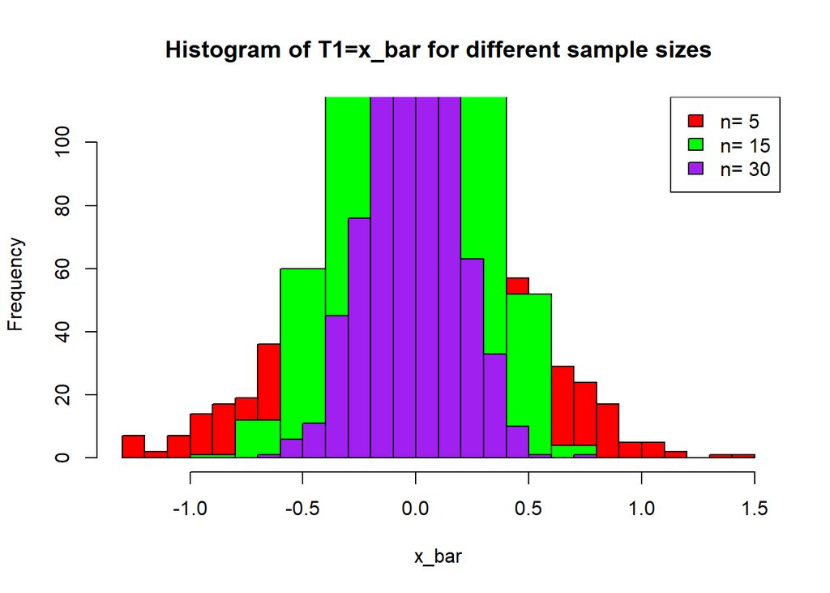

```r
n=c(5,15,30)
sam_mean_T1=sam_var_T1=sam_var_mean=sam_var_var=numeric(0)
T1_list=list()
T2_list=list()

for (i in 1:length(n)){
  x=matrix(rnorm(1000*n[i],0,1),nrow=1000,ncol=n[i])

  T1=apply(x,1,mean)
  x_var=apply(x,1,var)
  T2=((n[i]-1)/n[i])*x_var

  sam_mean_T1[i]=mean(T1)
  sam_var_mean[i]=mean(T2)

  sam_var_T1[i]=var(T1)
  sam_var_var[i]=var(T2)

  T1_list[[i]]=T1
  T2_list[[i]]=T2
}

hist(T1_list[[1]],breaks="FD",col="red",main="Histogram of T1=x_bar for different sample sizes",xlab="x_bar")
hist(T1_list[[2]],col="green",add=T)
hist(T1_list[[3]],col="purple",add=T)
legend("topright",legend=paste("n=",n),
       fill=c("red","green","purple"))
```

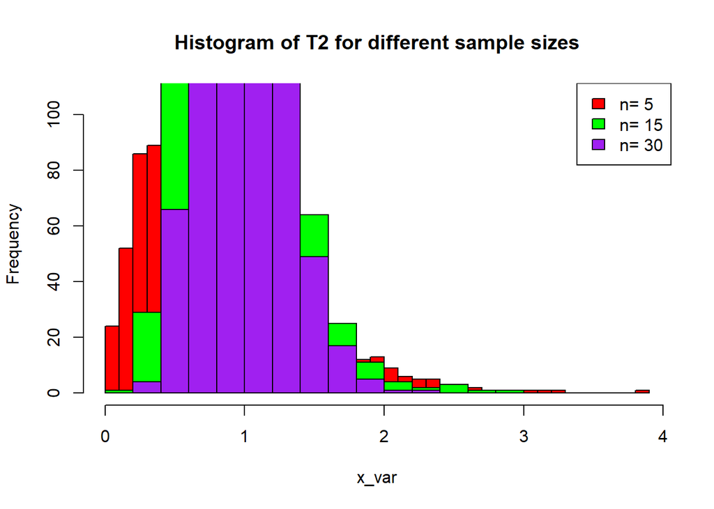

```r
hist(T2_list[[1]],breaks="FD",col="red",main="Histogram of T2 for different sample sizes",xlab="x_var")
hist(T2_list[[2]],col="green",add=T)
hist(T2_list[[3]],col="purple",add=T)
legend("topright",legend=paste("n=",n),
       fill=c("red","green","purple"))
```

```r
cbind(n,sam_mean_T1,sam_var_T1)
```

```
##       n  sam_mean_T1 sam_var_T1
## [1,]  5 -0.007841064 0.20157654
## [2,] 15 -0.010737263 0.06606033
## [3,] 30 -0.010725726 0.03325834
```

```r
cbind(n,sam_var_mean,sam_var_var)
```

```
##       n sam_var_mean sam_var_var
## [1,]  5    0.7996412  0.29974326
## [2,] 15    0.9542666  0.13052598
## [3,] 30    0.9757176  0.07515919
```

From this output, we conclude that as sample size increases,variability in the 1st moment estimator (T1=x_bar) is decreases.

2. Example To conduct the simulation study from U(0,$\theta$),$\theta$>0 distribution. Demonstrate the distribution and it’s descriptive statistics for different sample sizes of the moment estimator.

T1=$2\bar{x}$

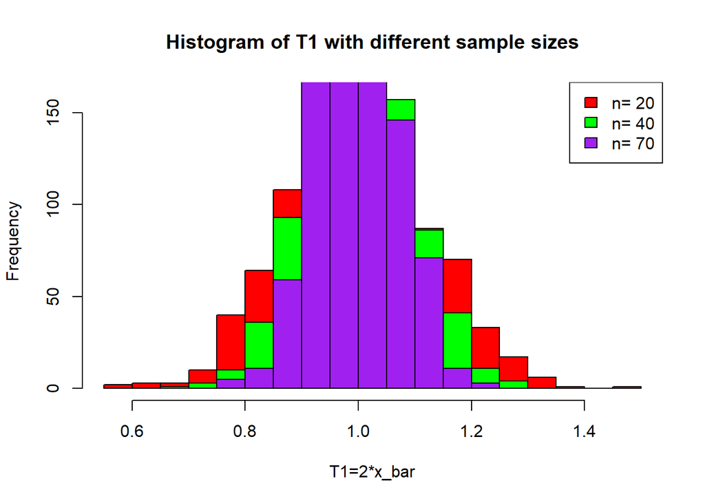

```r
n=c(20,40,70)
sam_mean_T1=sam_var_T1=numeric(length(n))
T1_list=list()

for (i in 1:length(n)){
  x=matrix(runif(1000*n[i],0,1),nrow = 1000,ncol = n[i])
  x_bar=apply(x,1,mean)
  T1=2*x_bar
  sam_mean_T1[i]=mean(T1)
  sam_var_T1[i]=var(T1)
  T1_list[[i]]=T1
}

hist(T1_list[[1]],breaks="FD",col="red",main="Histogram of T1 with different sample sizes",xlab="T1=2*x_bar")
hist(T1_list[[2]],col="green",add=T)
hist(T1_list[[3]],col="purple",add=T)


legend("topright",legend=paste("n=",n),
       fill=c("red","green","purple"))
```

```r
cbind(n,sam_mean_T1,sam_var_T1)
```

```
##       n sam_mean_T1  sam_var_T1
## [1,] 20   0.9990461 0.016359289
## [2,] 40   1.0012117 0.008680424
## [3,] 70   0.9983398 0.005020758
```

3. Example To conduct the simulation study from Gamma distribution with density given by $f(x|\alpha,\lambda)=\frac{\alpha^\lambda x^{\lambda - 1}e^{-\alpha x}}{\Gamma(\lambda)}\quad\text{for} x\geq0,\alpha>0, \lambda>0$. Demonstrate the distribution and it’s descriptive statistics for different sample sizes of following statistic/estimators.

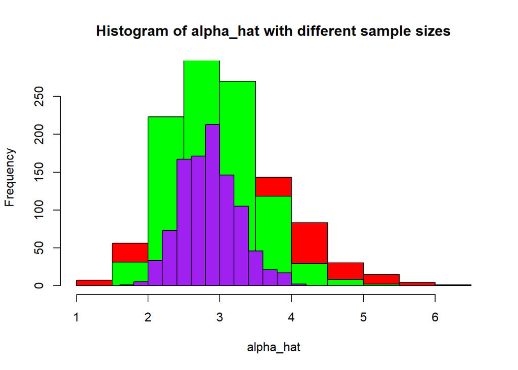

```r
rm(list=ls())
n=c(50,100,200) #To generate 5 r. s. from G(alpha=2.8, lambda(shape)=1.8) dist
set.seed(120)
sam_mean_alpha_hat=sam_mean_lambda_hat=sam_var_alpha_hat=sam_var_lambda_hat=numeric(length(n))

alpha_hat_list=list()
lambda_hat_list=list()

for (i in 1:length(n)){
  x=matrix(rgamma(1000*n[i],1.8,2.8),nrow=1000,ncol=n[i]) #shape=1.8

  m1_=apply(x,1,mean) #m1'
  m2_=apply(x^2,1,mean) #m2'
  m2=m2_-m1_^2 #m2=(1/n*sum(x-x_bar)^2)

  alpha_hat=m1_/m2 #moment est of alpha
  lambda_hat=m1_^2/m2  #moment estimate of lambda

  sam_mean_alpha_hat[i]=mean(alpha_hat)
  sam_mean_lambda_hat[i]=mean(lambda_hat)

  sam_var_alpha_hat[i]=var(alpha_hat)
  sam_var_lambda_hat[i]=var(lambda_hat)

  alpha_hat_list[i]=list(alpha_hat)
  lambda_hat_list[i]=list(lambda_hat)
}

hist(alpha_hat_list[[1]],col="red",main="Histogram of alpha_hat with different sample sizes",xlab="alpha_hat")
hist(alpha_hat_list[[2]],col="green",add=T)
hist(alpha_hat_list[[3]],col="purple",add=T)
```

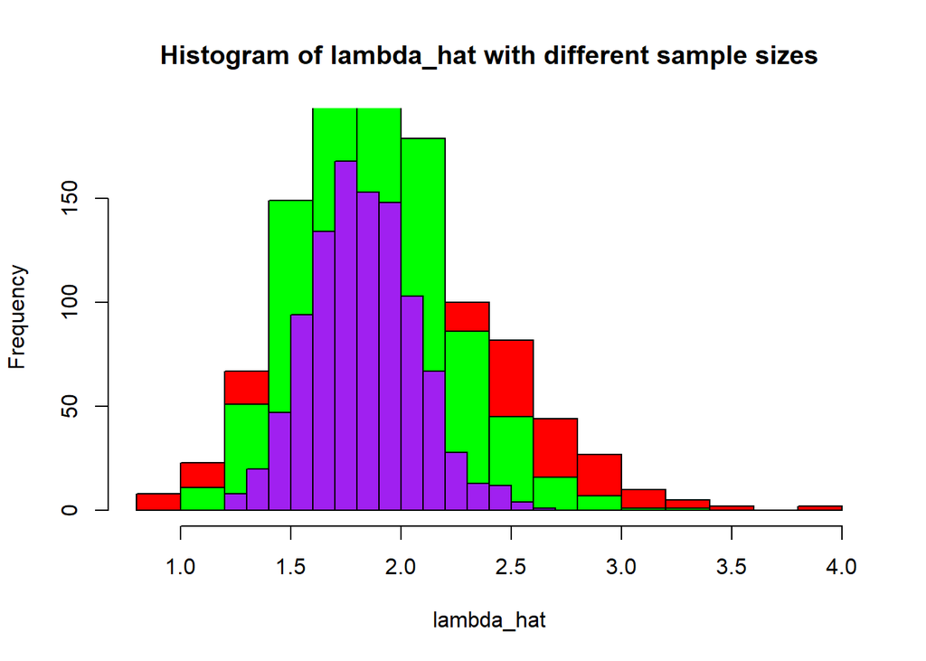

```r
hist(lambda_hat_list[[1]],col="red",main="Histogram of lambda_hat with different sample sizes",xlab="lambda_hat")
hist(lambda_hat_list[[2]],col="green",add=T)
hist(lambda_hat_list[[3]],col="purple",add=T)
```

```r
cbind(n,sam_mean_alpha_hat, sam_mean_lambda_hat)
```

```
##        n sam_mean_alpha_hat sam_mean_lambda_hat
## [1,]  50           3.077406            1.955498
## [2,] 100           2.926502            1.873718
## [3,] 200           2.859333            1.830444
```

```r
cbind(n,sam_var_alpha_hat,sam_var_lambda_hat)
```

```
##        n sam_var_alpha_hat sam_var_lambda_hat
## [1,]  50         0.6235670         0.20971140
## [2,] 100         0.3280680         0.11227818
## [3,] 200         0.1572297         0.05594251
```

4.Example To conduct the simulation study from Exponential distribution with location parameter $\mu$ and scale parameter $\sigma$. Demonstrate the distribution and it’s descriptive statistics for different sample sizes of following statistic/estimators for $\mu$ and $\sigma$ respectively.

1. $m_{1}'$-$\sqrt{m_{2}}$ 2)$\sqrt{m_{2}}$

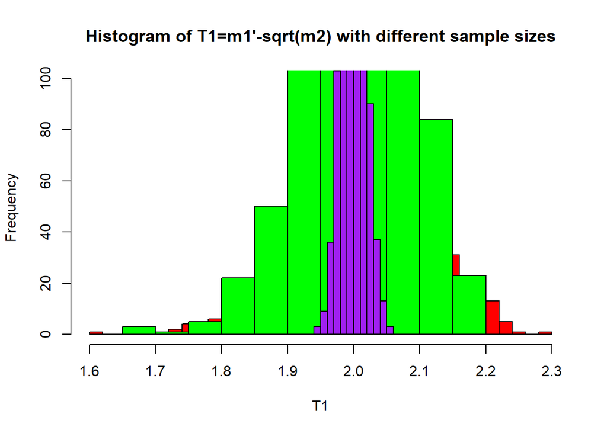

```r
n=c(100,150,3000)
sam_mean_T1=sam_var_T1=numeric(length(n))
sam_mean_T2=sam_var_T2=numeric(length(n))
mu=2
sigma=1

T1_list=list()
T2_list=list()

for (i in 1:length(n)){
  y=matrix(runif(1000*n[i],0,1),nrow = 1000,ncol = n[i])
  x=mu-(sigma*log(1-y))

  m1_=apply(x,1,mean) #m1'
  m2_=apply(x^2,1,mean) #m2'
  m2=m2_-((m1_)^2) #m2=(1/n*sum(x-x_bar)^2)

  T1=m1_-sqrt(m2)
  T2=sqrt(m2)

  sam_mean_T1[i]=mean(T1)
  sam_mean_T2[i]=mean(T2)

  sam_var_T1[i]=var(T1)
  sam_var_T2[i]=var(T2)

  T1_list[[i]]=T1
  T2_list[[i]]=T2

}

hist(T1_list[[1]],breaks="FD",col="red",main="Histogram of T1=m1'-sqrt(m2) with different sample sizes",xlab="T1")
hist(T1_list[[2]],col="green",add=T)
hist(T1_list[[3]],col="purple",add=T)
```

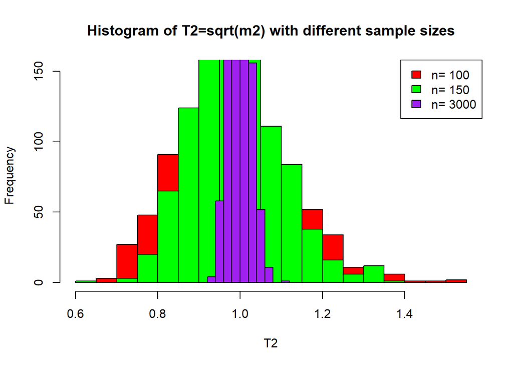

```r
hist(T2_list[[1]],breaks="FD",col="red",main="Histogram of T2=sqrt(m2) with different sample sizes",xlab="T2")
hist(T2_list[[2]],col="green",add=T)
hist(T2_list[[3]],col="purple",add=T)

legend("topright",legend=paste("n=",n),
       fill=c("red","green","purple"))
```

```r
cbind(n,sam_mean_T1,sam_var_T1)
```

```
##         n sam_mean_T1   sam_var_T1
## [1,]  100    2.019090 0.0086199415
## [2,]  150    2.010864 0.0059385257
## [3,] 3000    2.000307 0.0003435028
```

```r
cbind(n,sam_mean_T2,sam_var_T2)
```

```
##         n sam_mean_T2   sam_var_T2
## [1,]  100   0.9815215 0.0185036824
## [2,]  150   0.9892342 0.0120541253
## [3,] 3000   0.9999965 0.0006765653
```

5. Example Consider a random sample of size 20 from given below from $Beta(\alpha,\beta)$ distribution. Obtain moment estimates of and based on given sample.

```r
x=c(0.133904,0.224011,0.062282,0.122690,0.051213,0.620577,0.000650,0.271087,0.827109,0.929479,0.561905,0.160865,
    0.362565,0.001039,0.883135,0.393477,0.990179,0.045737,0.243155,0.080471)
n=length(x)
x_bar=mean(x)
var_x=var(x)*(n-1)/n
alpha_hat=x_bar*(x_bar-mean(x^2))/var_x
beta_hat=(1-x_bar)*alpha_hat/x_bar
cbind(alpha_hat,beta_hat)
```

```
##      alpha_hat  beta_hat
## [1,] 0.3952689 0.7396595
```